# LME Analysis of NUCs

Antoin Rodgers

18.05.2022

## L targets

### Analysis of L timing

- intercepts only model

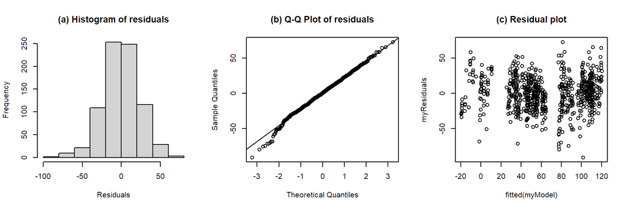

```
## Formula:  l_t ~ foot_syls + pre_syls + fin_phon + nuc_new_word + gender + (1 | speaker) + (1 | speech_rate) + (1 | nuc_pre_text)
##
## Linear mixed model fit by REML. t-tests use Satterthwaite's method [
## lmerModLmerTest]
## Formula: l_t_equation
##    Data: nuc_data
## Control:
## lmerControl(optimizer = optimizer, calc.derivs = FALSE, optCtrl = list(method = "nlminb",
##     starttests = FALSE, kkt = FALSE))
##
## REML criterion at convergence: 7246.3
##
## Scaled residuals:
##     Min      1Q  Median      3Q     Max
## -3.8104 -0.6441  0.0064  0.6429  3.0503
##
## Random effects:
##  Groups       Name        Variance Std.Dev.
##  speech_rate  (Intercept)  12.81    3.579
##  nuc_pre_text (Intercept) 286.73   16.933
##  speaker      (Intercept) 149.00   12.207
##  Residual                 567.12   23.814
## Number of obs: 788, groups:  speech_rate, 636; nuc_pre_text, 12; speaker, 11
##
## Fixed effects:
##               Estimate Std. Error      df t value Pr(>|t|)
## (Intercept)    104.017     17.909   5.761   5.808  0.00132 **
## foot_syls2       2.137     24.352   4.942   0.088  0.93350
## foot_syls3       3.024      3.494 705.842   0.865  0.38714
## foot_syls4     -14.528     28.125   4.946  -0.517  0.62773
## pre_syls1       -7.775     24.204   4.823  -0.321  0.76149
## pre_syls2      -11.807     31.143   4.881  -0.379  0.72054
## pre_syls3      -38.223     31.145   4.882  -1.227  0.27560
## fin_phonL%       2.959      5.459 772.884   0.542  0.58799
## nuc_new_word0   20.228     14.076   4.966   1.437  0.21061
## genderM        -54.108      7.592   8.963  -7.127 5.62e-05 ***
## ---
## Signif. codes:  0 '***' 0.001 '**' 0.01 '*' 0.05 '.' 0.1 ' ' 1
##
## Correlation of Fixed Effects:
```

[output cut: 24 more lines]

```
## Degrees of freedom method: Satterthwaite
##
##              Eliminated  Sum Sq Mean Sq NumDF  DenDF F value    Pr(>F)
## foot_syls             1   653.3   217.8     3   6.42  0.3755    0.7740
## fin_phon              2   201.7   201.7     1 774.75  0.3480    0.5554
## nuc_new_word          3  1281.5  1281.5     1   6.96  2.2122    0.1808
## pre_syls              4  4393.8  1464.6     3   7.91  2.5283    0.1316
## gender                0 29977.8 29977.8     1   8.99 51.7515 5.144e-05 ***
## ---
## Signif. codes:  0 '***' 0.001 '**' 0.01 '*' 0.05 '.' 0.1 ' ' 1
##
## Model found:
## l_t ~ gender + (1 | speaker) + (1 | nuc_pre_text)
##
## isSingular(my_model, tol = 1e-05 ) --> FALSE
```

Anova of model: l_t ~ foot_syls + pre_syls + fin_phon + nuc_new_word + gender + (1 | speaker) + (1 | speech_rate) + (1 | nuc_pre_text)

| term | sumsq | meansq | NumDF | DenDF | F value | p.value | signif. |
| --- | --- | --- | --- | --- | --- | --- | --- |
| foot_syls | 657.394 | 219.131 | 3 | 6.420 | 0.386 | 7.668217e-01 |  |
| pre_syls | 3207.008 | 1069.003 | 3 | 4.919 | 1.885 | 2.514947e-01 |  |
| fin_phon | 166.588 | 166.588 | 1 | 772.884 | 0.294 | 5.879858e-01 |  |
| nuc_new_word | 1171.074 | 1171.074 | 1 | 4.966 | 2.065 | 2.106091e-01 |  |
| gender | 28808.630 | 28808.630 | 1 | 8.963 | 50.799 | 5.616803e-05 | p<0.001 |

[[1]]

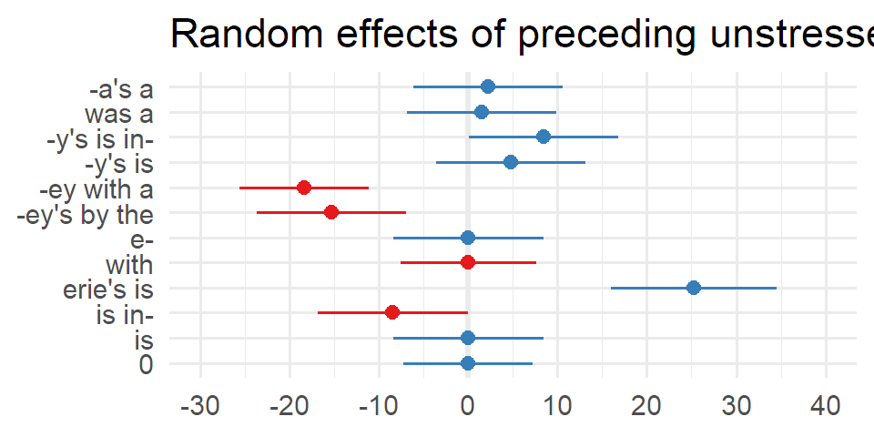

Conditional and marginal R<sup>2</sup> of model

| R2_conditional | R2_marginal |
| --- | --- |
| 0.71 | 0.48 |

$foot_syls

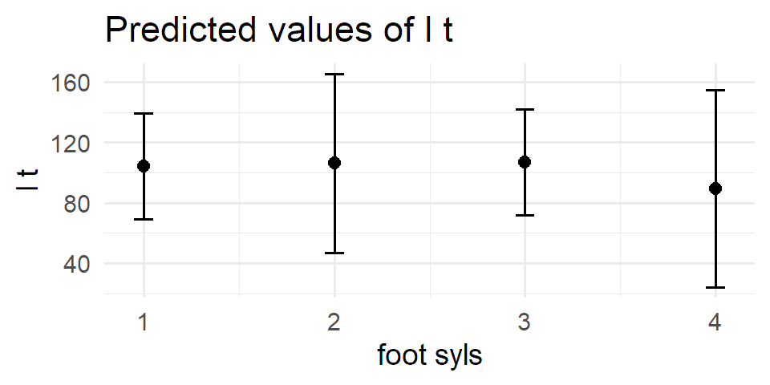

$pre_syls

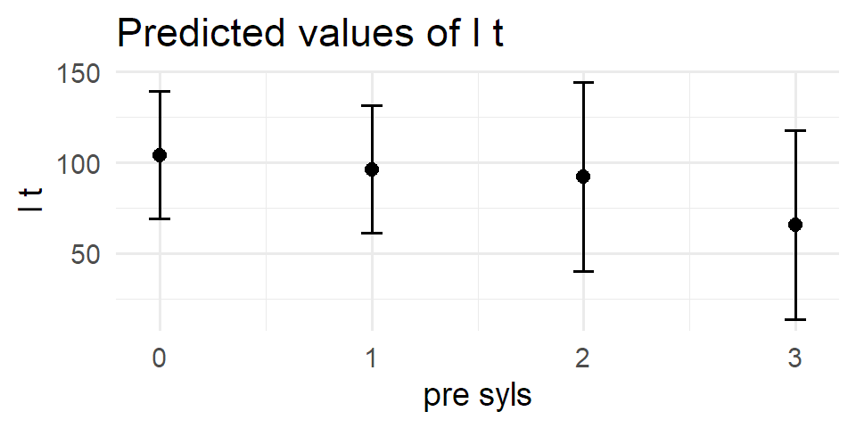

$fin_phon

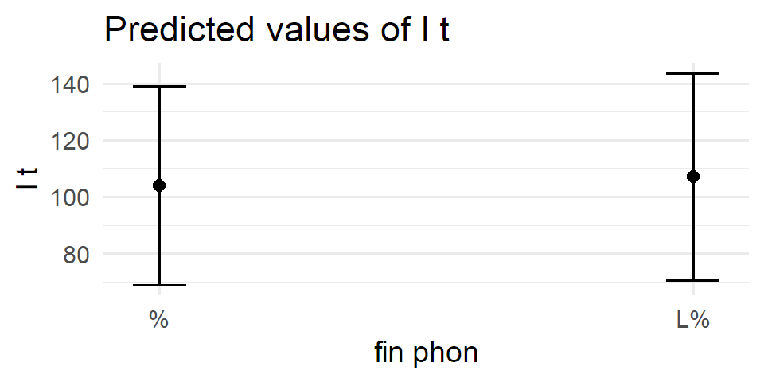

$nuc_new_word

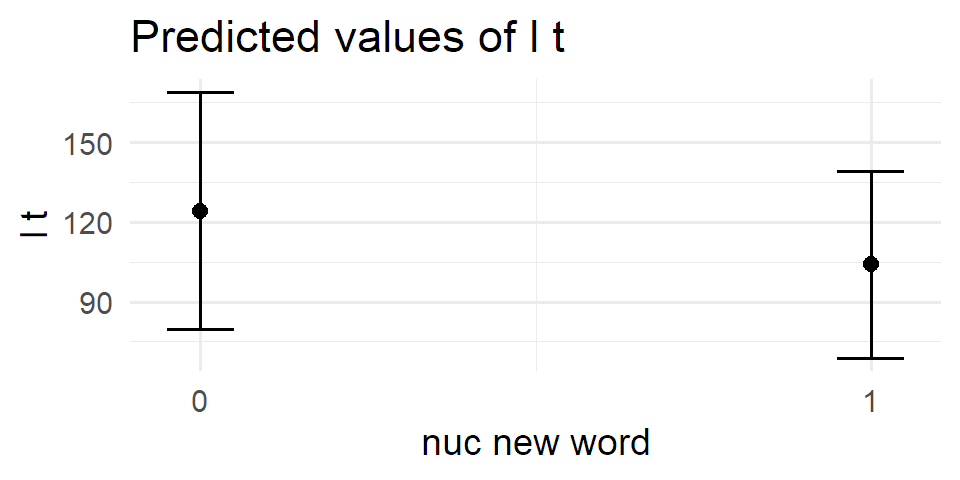

$gender

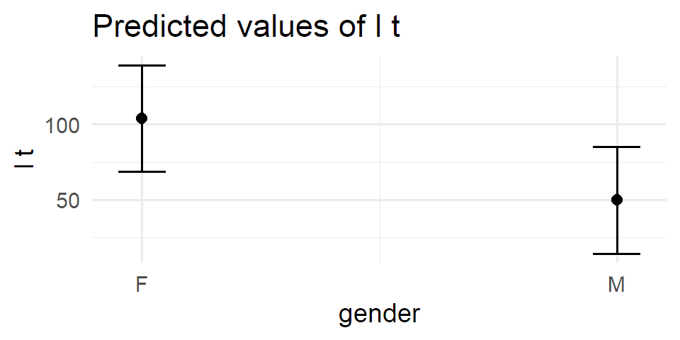

summary of model: l_t ~ foot_syls + pre_syls + fin_phon + nuc_new_word + gender + (1 | speaker) + (1 | speech_rate) + (1 | nuc_pre_text)

| term | estimate | conf.low | conf.high | std.error | t.value | df | p.value |
| --- | --- | --- | --- | --- | --- | --- | --- |
| (Intercept) | 104.017 | 59.752483 | 148.282144 | 17.909 | 5.808 | 5.76 | 0.0013 |
| foot_syls2 | 2.137 | -60.681396 | 64.956254 | 24.352 | 0.088 | 4.94 | 0.9335 |
| foot_syls3 | 3.024 | -3.836631 | 9.884055 | 3.494 | 0.865 | 705.84 | 0.3871 |
| foot_syls4 | -14.528 | -87.061574 | 58.006364 | 28.125 | -0.517 | 4.95 | 0.6277 |
| pre_syls1 | -7.775 | -70.684866 | 55.135199 | 24.204 | -0.321 | 4.82 | 0.7615 |
| pre_syls2 | -11.807 | -92.455045 | 68.841560 | 31.143 | -0.379 | 4.88 | 0.7205 |
| pre_syls3 | -38.223 | -118.870728 | 42.425304 | 31.145 | -1.227 | 4.88 | 0.2756 |
| fin_phonL% | 2.959 | -7.757335 | 13.674563 | 5.459 | 0.542 | 772.88 | 0.588 |
| nuc_new_word0 | 20.228 | -16.032134 | 56.487267 | 14.076 | 1.437 | 4.97 | 0.2106 |
| genderM | -54.108 | -71.292366 | -36.923785 | 7.592 | -7.127 | 8.96 | 5.6e-05 |

b0 for l_t ~ foot_syls + pre_syls + fin_phon + nuc_new_word + gender + (1 | speaker) + (1 | speech_rate) + (1 | nuc_pre_text)

| intercept | estimate | conf.low | conf.high | std.error | t.value | df | p.value |
| --- | --- | --- | --- | --- | --- | --- | --- |
| foot_syls1 | 104 | 59.8 | 148.3 | 17.909 | 5.808 | 5.76 | 0.001 |
| foot_syls2 | 106.2 | 29.4 | 182.9 | 30.147 | 3.521 | 5.16 | 0.016 |
| foot_syls3 | 107 | 62.8 | 151.3 | 17.908 | 5.977 | 5.76 | 0.001 |
| foot_syls4 | 89.5 | 4.577 | 174.4 | 33.270 | 2.690 | 5.12 | 0.042 |
| pre_syls0 | 104 | 59.8 | 148.3 | 17.909 | 5.808 | 5.76 | 0.001 |
| pre_syls1 | 96.2 | 52 | 140.5 | 17.917 | 5.372 | 5.77 | 0.002 |
| pre_syls2 | 92.2 | 25.2 | 159.3 | 26.552 | 3.473 | 5.32 | 0.016 |
| pre_syls3 | 65.8 | -1.252 | 132.8 | 26.555 | 2.478 | 5.32 | 0.053 |

b1 for l_t ~ foot_syls + pre_syls + fin_phon + nuc_new_word + gender + (1 | speaker) + (1 | speech_rate) + (1 | nuc_pre_text)

| intercept | slope | estimate | conf.low | conf.high | std.error | t.value | df | p.value |
| --- | --- | --- | --- | --- | --- | --- | --- | --- |
| foot_syls1 | foot_syls2 | 2.137 | -60.7 | 65 | 24.352 | 0.088 | 4.94 | 0.934 |
| foot_syls1 | foot_syls3 | 3.024 | -3.837 | 9.884 | 3.494 | 0.865 | 705.84 | 0.387 |
| foot_syls1 | foot_syls4 | -14.5 | -87.1 | 58 | 28.125 | -0.517 | 4.95 | 0.628 |
| foot_syls2 | foot_syls3 | 0.886 | -61.9 | 63.7 | 24.404 | 0.036 | 4.98 | 0.972 |
| foot_syls2 | foot_syls4 | -16.7 | -89.2 | 55.8 | 28.160 | -0.592 | 4.97 | 0.58 |
| foot_syls3 | foot_syls4 | -17.6 | -90.1 | 55 | 28.166 | -0.623 | 4.98 | 0.561 |
| pre_syls0 | pre_syls1 | -7.775 | -70.7 | 55.1 | 24.204 | -0.321 | 4.82 | 0.761 |
| pre_syls0 | pre_syls2 | -11.8 | -92.5 | 68.8 | 31.143 | -0.379 | 4.88 | 0.721 |
| pre_syls0 | pre_syls3 | -38.2 | -118.9 | 42.4 | 31.145 | -1.227 | 4.88 | 0.276 |
| pre_syls1 | pre_syls2 | -4.032 | -54.5 | 46.4 | 19.597 | -0.206 | 4.97 | 0.845 |
| pre_syls1 | pre_syls3 | -30.4 | -80.9 | 20 | 19.598 | -1.554 | 4.97 | 0.181 |
| pre_syls2 | pre_syls3 | -26.4 | -57.8 | 4.987 | 12.191 | -2.167 | 4.97 | 0.083 |
| intercept | fin_phonL% | 2.959 | -7.757 | 13.7 | 5.459 | 0.542 | 772.88 | 0.588 |
| intercept | nuc_new_word0 | 20.2 | -16 | 56.5 | 14.076 | 1.437 | 4.97 | 0.211 |
| intercept | genderM | -54.1 | -71.3 | -36.9 | 7.592 | -7.127 | 8.96 | 5.6e-05 |

### Analysis of L F0

- Only intercepts only model avoided convergence and singularity issues
- Speech rate caused massive estimation issues
- model needs trimming (|sd| residuals > 3)

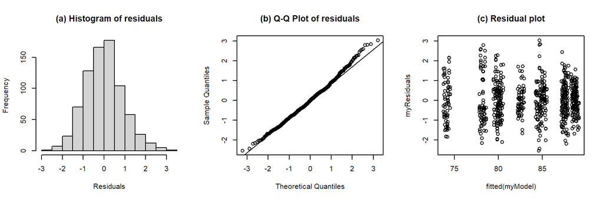

```
## Formula:  l_f0 ~ foot_syls + pre_syls + fin_phon + nuc_new_word + (1 | speaker) + (1 | nuc_pre_text)
##
## Linear mixed model fit by REML. t-tests use Satterthwaite's method [
## lmerModLmerTest]
## Formula: l_f0_equation
##    Data: nuc_l_f0.trimmed
## Control:
## lmerControl(optimizer = optimizer, calc.derivs = FALSE, optCtrl = list(method = "nlminb",
##     starttests = FALSE, kkt = FALSE))
##
## REML criterion at convergence: 2179.7
##
## Scaled residuals:
##     Min      1Q  Median      3Q     Max
## -2.7454 -0.6776 -0.0210  0.5898  3.2783
##
## Random effects:
##  Groups       Name        Variance Std.Dev.
##  nuc_pre_text (Intercept)  0.02613 0.1616
##  speaker      (Intercept) 23.21554 4.8183
##  Residual                  0.85260 0.9234
## Number of obs: 778, groups:  nuc_pre_text, 12; speaker, 11
##
## Fixed effects:
##                Estimate Std. Error        df t value Pr(>|t|)
## (Intercept)    83.01527    1.46598  10.35110  56.628 3.05e-14 ***
## foot_syls2      0.50994    0.28559   5.36943   1.786  0.13020
## foot_syls3      0.46440    0.13420 754.49779   3.460  0.00057 ***
## foot_syls4      0.87237    0.32976   5.36131   2.645  0.04264 *
## pre_syls1       0.12411    0.26565   4.02000   0.467  0.66457
## pre_syls2      -0.14675    0.35308   4.63058  -0.416  0.69623
## pre_syls3      -0.14541    0.35294   4.60703  -0.412  0.69879
## fin_phonL%     -0.02984    0.20960 759.11117  -0.142  0.88682
## nuc_new_word0  -0.24504    0.16622   5.51400  -1.474  0.19512
## ---
## Signif. codes:  0 '***' 0.001 '**' 0.01 '*' 0.05 '.' 0.1 ' ' 1
##
## Correlation of Fixed Effects:
##             (Intr) ft_sy2 ft_sy3 ft_sy4 pr_sy1 pr_sy2 pr_sy3 fn_pL%
## foot_syls2  -0.009
```

[output cut: 19 more lines]

```
## Backward reduced fixed-effect table:
## Degrees of freedom method: Satterthwaite
##
##              Eliminated  Sum Sq Mean Sq NumDF  DenDF F value  Pr(>F)
## fin_phon              1  0.0173  0.0173     1 759.11  0.0203 0.88682
## pre_syls              2  1.4632  0.4877     3   4.91  0.5728 0.65753
## nuc_new_word          3  3.1494  3.1494     1   8.55  3.6976 0.08837 .
## foot_syls             0 13.4482  4.4827     3  12.06  5.2637 0.01496 *
## ---
## Signif. codes:  0 '***' 0.001 '**' 0.01 '*' 0.05 '.' 0.1 ' ' 1
##
## Model found:
## l_f0 ~ foot_syls + (1 | speaker) + (1 | nuc_pre_text)
##
## isSingular(my_model, tol = 1e-05 ) --> FALSE
```

Anova of model: l_f0 ~ foot_syls + pre_syls + fin_phon + nuc_new_word + (1 | speaker) + (1 | nuc_pre_text)

| term | sumsq | meansq | NumDF | DenDF | F value | p.value | signif. |
| --- | --- | --- | --- | --- | --- | --- | --- |
| foot_syls | 14.041 | 4.680 | 3 | 7.286 | 5.490 | 0.02781944 | p<0.05 |
| pre_syls | 1.462 | 0.487 | 3 | 4.907 | 0.572 | 0.65823647 |  |
| fin_phon | 0.017 | 0.017 | 1 | 759.111 | 0.020 | 0.88682022 |  |
| nuc_new_word | 1.853 | 1.853 | 1 | 5.514 | 2.173 | 0.19511848 |  |

Conditional and marginal R<sup>2</sup> of model

| R2_conditional | R2_marginal |
| --- | --- |
| 0.96 | 0 |

$foot_syls

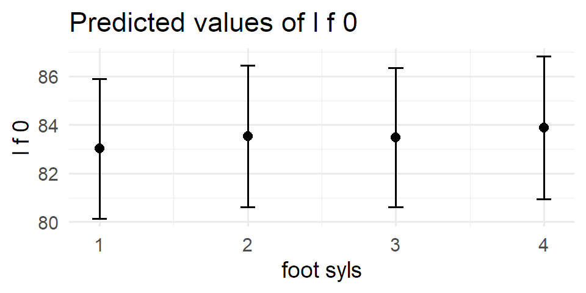

$pre_syls

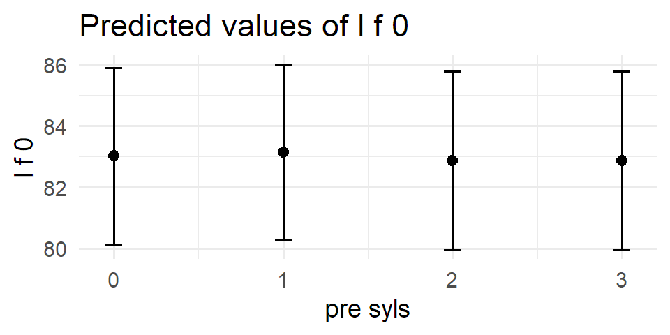

$fin_phon

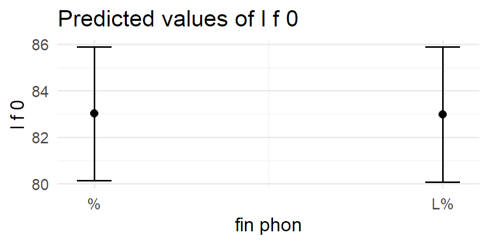

$nuc_new_word

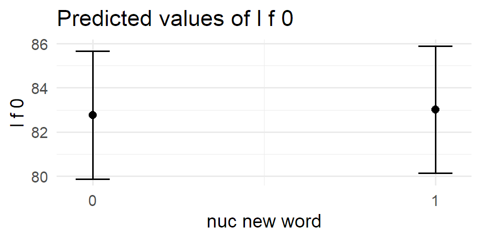

summary of model: l_f0 ~ foot_syls + pre_syls + fin_phon + nuc_new_word + (1 | speaker) + (1 | nuc_pre_text)

| term | estimate | conf.low | conf.high | std.error | t.value | df | p.value |
| --- | --- | --- | --- | --- | --- | --- | --- |
| (Intercept) | 83.015 | 79.76382258 | 86.2667261 | 1.466 | 56.628 | 10.35 | 3.1e-14 |
| foot_syls2 | 0.510 | -0.20926780 | 1.2291435 | 0.286 | 1.786 | 5.37 | 0.1302 |
| foot_syls3 | 0.464 | 0.20094043 | 0.7278538 | 0.134 | 3.460 | 754.50 | 6e-04 |
| foot_syls4 | 0.872 | 0.04158245 | 1.7031610 | 0.330 | 2.645 | 5.36 | 0.0426 |
| pre_syls1 | 0.124 | -0.61202153 | 0.8602389 | 0.266 | 0.467 | 4.02 | 0.6646 |
| pre_syls2 | -0.147 | -1.07658150 | 0.7830806 | 0.353 | -0.416 | 4.63 | 0.6962 |
| pre_syls3 | -0.145 | -1.07644484 | 0.7856155 | 0.353 | -0.412 | 4.61 | 0.6988 |
| fin_phonL% | -0.030 | -0.44130302 | 0.3816192 | 0.210 | -0.142 | 759.11 | 0.8868 |
| nuc_new_word0 | -0.245 | -0.66061758 | 0.1705454 | 0.166 | -1.474 | 5.51 | 0.1951 |

b0 for l_f0 ~ foot_syls + pre_syls + fin_phon + nuc_new_word + (1 | speaker) + (1 | nuc_pre_text)

| intercept | estimate | conf.low | conf.high | std.error | t.value | df | p.value |
| --- | --- | --- | --- | --- | --- | --- | --- |
| foot_syls1 | 83 | 79.8 | 86.3 | 1.466 | 56.628 | 10.35 | 3.1e-14 |
| foot_syls2 | 83.5 | 80.2 | 86.8 | 1.491 | 56.021 | 11.01 | 7.0e-15 |
| foot_syls3 | 83.5 | 80.2 | 86.7 | 1.466 | 56.945 | 10.35 | 2.9e-14 |
| foot_syls4 | 83.9 | 80.6 | 87.2 | 1.500 | 55.920 | 11.25 | 4.1e-15 |
| pre_syls0 | 83 | 79.8 | 86.3 | 1.466 | 56.628 | 10.35 | 3.1e-14 |
| pre_syls1 | 83.1 | 79.9 | 86.4 | 1.466 | 56.699 | 10.36 | 2.9e-14 |
| pre_syls2 | 82.9 | 79.6 | 86.1 | 1.485 | 55.816 | 10.86 | 1.1e-14 |
| pre_syls3 | 82.9 | 79.6 | 86.1 | 1.485 | 55.817 | 10.86 | 1.1e-14 |

b1 for l_f0 ~ foot_syls + pre_syls + fin_phon + nuc_new_word + (1 | speaker) + (1 | nuc_pre_text)

| intercept | slope | estimate | conf.low | conf.high | std.error | t.value | df | p.value |
| --- | --- | --- | --- | --- | --- | --- | --- | --- |
| foot_syls1 | foot_syls2 | 0.51 | -0.209 | 1.229 | 0.286 | 1.786 | 5.37 | 0.13 |
| foot_syls1 | foot_syls3 | 0.464 | 0.201 | 0.728 | 0.134 | 3.460 | 754.50 | 5.7e-04 |
| foot_syls1 | foot_syls4 | 0.872 | 0.042 | 1.703 | 0.330 | 2.645 | 5.36 | 0.043 |
| foot_syls2 | foot_syls3 | -0.046 | -0.764 | 0.673 | 0.291 | -0.156 | 5.82 | 0.881 |
| foot_syls2 | foot_syls4 | 0.362 | -0.468 | 1.192 | 0.334 | 1.086 | 5.63 | 0.322 |
| foot_syls3 | foot_syls4 | 0.408 | -0.422 | 1.238 | 0.334 | 1.220 | 5.67 | 0.271 |
| pre_syls0 | pre_syls1 | 0.124 | -0.612 | 0.86 | 0.266 | 0.467 | 4.02 | 0.665 |
| pre_syls0 | pre_syls2 | -0.147 | -1.077 | 0.783 | 0.353 | -0.416 | 4.63 | 0.696 |
| pre_syls0 | pre_syls3 | -0.145 | -1.076 | 0.786 | 0.353 | -0.412 | 4.61 | 0.699 |
| pre_syls1 | pre_syls2 | -0.271 | -0.848 | 0.307 | 0.233 | -1.165 | 5.66 | 0.291 |
| pre_syls1 | pre_syls3 | -0.27 | -0.848 | 0.309 | 0.232 | -1.161 | 5.57 | 0.293 |
| pre_syls2 | pre_syls3 | 0.001 | -0.36 | 0.362 | 0.144 | 0.009 | 5.43 | 0.993 |
| intercept | fin_phonL% | -0.03 | -0.441 | 0.382 | 0.210 | -0.142 | 759.11 | 0.887 |
| intercept | nuc_new_word0 | -0.245 | -0.661 | 0.171 | 0.166 | -1.474 | 5.51 | 0.195 |

## H targets

### Analysis of H timing

- Only intercepts only model avoided convergence and singularity issues
- Singularity continues, so redundant `nuc_new_word` factor removed as per `step()` output

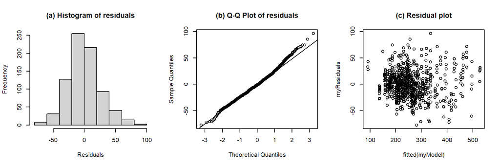

```
## Formula:  h_t ~ foot_syls + pre_syls + fin_phon + gender + (1 | speaker) + (1 | speech_rate) + (1 | foot_dur) + (1 | nuc_pre_text)
##
## Linear mixed model fit by REML. t-tests use Satterthwaite's method [
## lmerModLmerTest]
## Formula: h_t_equation
##    Data: nuc_data
## Control:
## lmerControl(optimizer = optimizer, calc.derivs = FALSE, optCtrl = list(method = "nlminb",
##     starttests = FALSE, kkt = FALSE))
##
## REML criterion at convergence: 7423.4
##
## Scaled residuals:
##     Min      1Q  Median      3Q     Max
## -2.9199 -0.6672 -0.0533  0.5848  3.6290
##
## Random effects:
##  Groups       Name        Variance  Std.Dev.
##  speech_rate  (Intercept) 1.102e-03  0.03319
##  foot_dur     (Intercept) 1.078e+01  3.28333
##  nuc_pre_text (Intercept) 2.891e+02 17.00439
##  speaker      (Intercept) 5.920e+02 24.33071
##  Residual                 7.014e+02 26.48443
## Number of obs: 788, groups:
## speech_rate, 636; foot_dur, 316; nuc_pre_text, 12; speaker, 11
##
## Fixed effects:
##             Estimate Std. Error      df t value Pr(>|t|)
## (Intercept)  282.109     19.976   9.794  14.122 7.81e-08 ***
## foot_syls2    21.496     24.541   5.990   0.876  0.41480
## foot_syls3    96.893      3.874 711.149  25.013  < 2e-16 ***
## foot_syls4   231.608     24.540   5.990   9.438 8.13e-05 ***
## pre_syls1    -34.298     24.360   5.816  -1.408  0.21029
## pre_syls2    -23.793     31.160   5.896  -0.764  0.47456
## pre_syls3    -56.469     31.163   5.898  -1.812  0.12078
## fin_phonL%   -45.677      6.067 767.590  -7.529 1.43e-13 ***
## genderM      -64.228     14.858   9.007  -4.323  0.00192 **
## ---
## Signif. codes:  0 '***' 0.001 '**' 0.01 '*' 0.05 '.' 0.1 ' ' 1
##
```

[output cut: 24 more lines]

```
## Backward reduced fixed-effect table:
## Degrees of freedom method: Satterthwaite
##
##           Eliminated Sum Sq Mean Sq NumDF  DenDF  F value    Pr(>F)
## pre_syls           1   6480    2160     3   5.96   3.0335  0.115362
## foot_syls          0 507997  169332     3  12.60 237.8269 2.390e-11 ***
## fin_phon           0  41110   41110     1 768.68  57.7391 8.715e-14 ***
## gender             0  13315   13315     1   9.01  18.7003  0.001918 **
## ---
## Signif. codes:  0 '***' 0.001 '**' 0.01 '*' 0.05 '.' 0.1 ' ' 1
##
## Model found:
## h_t ~ foot_syls + fin_phon + gender + (1 | speaker) + (1 | nuc_pre_text)
##
## isSingular(my_model, tol = 1e-05 ) --> FALSE
```

Anova of model: h_t ~ foot_syls + pre_syls + fin_phon + gender + (1 | speaker) + (1 | speech_rate) + (1 | foot_dur) + (1 | nuc_pre_text)

| term | sumsq | meansq | NumDF | DenDF | F value | p.value | signif. |
| --- | --- | --- | --- | --- | --- | --- | --- |
| foot_syls | 501635.128 | 167211.709 | 3 | 7.990 | 238.389 | 3.729457e-08 | p<0.001 |
| pre_syls | 6419.201 | 2139.734 | 3 | 5.954 | 3.051 | 1.143944e-01 |  |
| fin_phon | 39762.831 | 39762.831 | 1 | 767.590 | 56.689 | 1.434684e-13 | p<0.001 |
| gender | 13107.759 | 13107.759 | 1 | 9.007 | 18.687 | 1.921334e-03 | p<0.01 |

Conditional and marginal R<sup>2</sup> of model

| R2_conditional | R2_marginal |
| --- | --- |
| 0.89 | 0.76 |

$foot_syls

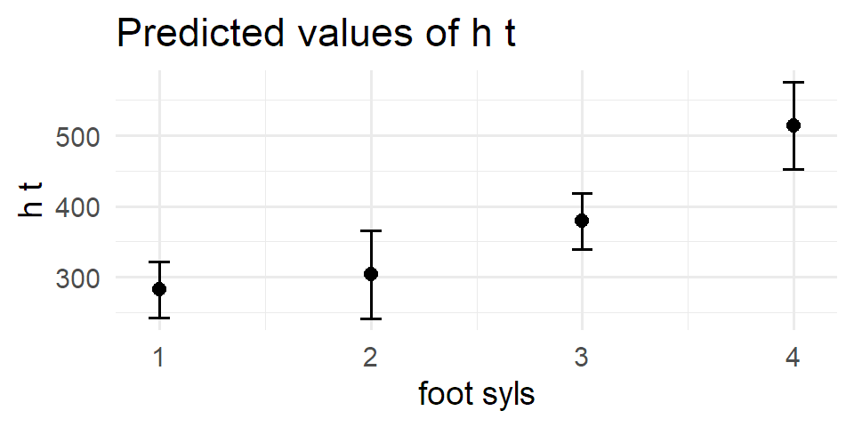

$pre_syls

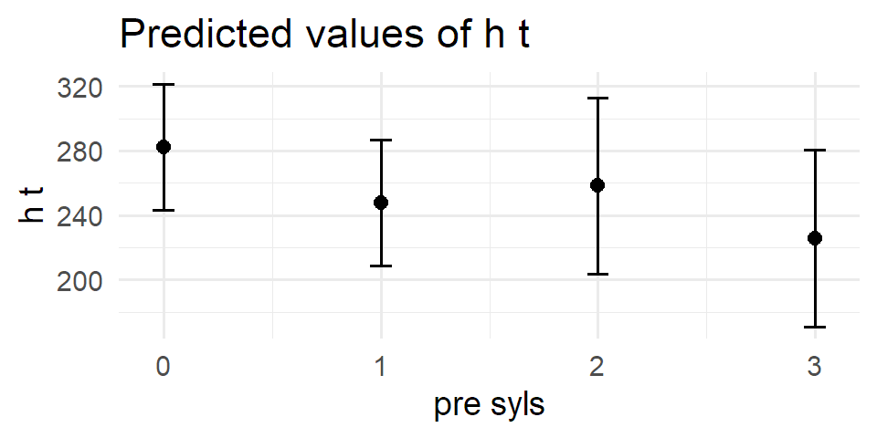

$fin_phon

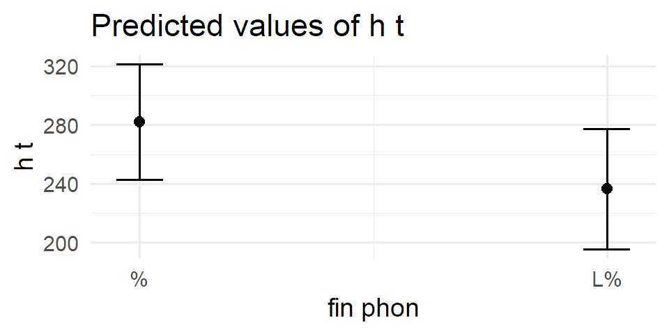

$gender

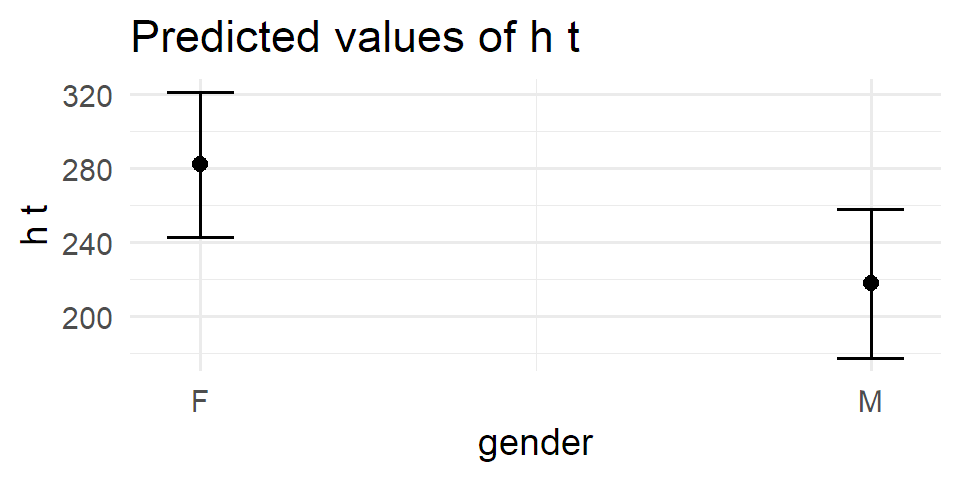

summary of model: h_t ~ foot_syls + pre_syls + fin_phon + gender + (1 | speaker) + (1 | speech_rate) + (1 | foot_dur) + (1 | nuc_pre_text)

| term | estimate | conf.low | conf.high | std.error | t.value | df | p.value |
| --- | --- | --- | --- | --- | --- | --- | --- |
| (Intercept) | 282.109 | 237.47171 | 326.74556 | 19.976 | 14.122 | 9.79 | 7.8e-08 |
| foot_syls2 | 21.496 | -38.57736 | 81.56960 | 24.541 | 0.876 | 5.99 | 0.4148 |
| foot_syls3 | 96.893 | 89.28724 | 104.49793 | 3.874 | 25.013 | 711.15 | 1.5e-99 |
| foot_syls4 | 231.608 | 171.53549 | 291.68112 | 24.540 | 9.438 | 5.99 | 8.1e-05 |
| pre_syls1 | -34.298 | -94.36678 | 25.77035 | 24.360 | -1.408 | 5.82 | 0.2103 |
| pre_syls2 | -23.793 | -100.36681 | 52.78036 | 31.160 | -0.764 | 5.90 | 0.4746 |
| pre_syls3 | -56.469 | -133.04325 | 20.10493 | 31.163 | -1.812 | 5.90 | 0.1208 |
| fin_phonL% | -45.677 | -57.58653 | -33.76798 | 6.067 | -7.529 | 767.59 | 1.4e-13 |
| genderM | -64.228 | -97.83357 | -30.62164 | 14.858 | -4.323 | 9.01 | 0.0019 |

b0 for h_t ~ foot_syls + pre_syls + fin_phon + gender + (1 | speaker) + (1 | speech_rate) + (1 | foot_dur) + (1 | nuc_pre_text)

| intercept | estimate | conf.low | conf.high | std.error | t.value | df | p.value |
| --- | --- | --- | --- | --- | --- | --- | --- |
| foot_syls1 | 282.1 | 237.5 | 326.7 | 19.976 | 14.122 | 9.79 | 7.8e-08 |
| foot_syls2 | 303.6 | 229.4 | 377.8 | 31.546 | 9.624 | 7.21 | 2.3e-05 |
| foot_syls3 | 379 | 334.4 | 423.6 | 19.974 | 18.974 | 9.79 | 4.8e-09 |
| foot_syls4 | 513.7 | 439.5 | 587.9 | 31.547 | 16.284 | 7.18 | 6.2e-07 |
| pre_syls0 | 282.1 | 237.5 | 326.7 | 19.976 | 14.122 | 9.79 | 7.8e-08 |
| pre_syls1 | 247.8 | 203.2 | 292.5 | 19.987 | 12.399 | 9.82 | 2.6e-07 |
| pre_syls2 | 258.3 | 193.7 | 322.9 | 27.875 | 9.267 | 7.77 | 1.8e-05 |
| pre_syls3 | 225.6 | 161 | 290.3 | 27.877 | 8.094 | 7.76 | 4.8e-05 |

b1 for h_t ~ foot_syls + pre_syls + fin_phon + gender + (1 | speaker) + (1 | speech_rate) + (1 | foot_dur) + (1 | nuc_pre_text)

| intercept | slope | estimate | conf.low | conf.high | std.error | t.value | df | p.value |
| --- | --- | --- | --- | --- | --- | --- | --- | --- |
| foot_syls1 | foot_syls2 | 21.5 | -38.6 | 81.6 | 24.541 | 0.876 | 5.99 | 0.415 |
| foot_syls1 | foot_syls3 | 96.9 | 89.3 | 104.5 | 3.874 | 25.013 | 711.15 | 1.5e-99 |
| foot_syls1 | foot_syls4 | 231.6 | 171.5 | 291.7 | 24.540 | 9.438 | 5.99 | 8.1e-05 |
| foot_syls2 | foot_syls3 | 75.4 | 15.3 | 135.5 | 24.603 | 3.065 | 6.05 | 0.022 |
| foot_syls2 | foot_syls4 | 210.1 | 150 | 270.2 | 24.584 | 8.547 | 6.03 | 1.4e-04 |
| foot_syls3 | foot_syls4 | 134.7 | 74.6 | 194.8 | 24.597 | 5.477 | 6.05 | 0.002 |
| pre_syls0 | pre_syls1 | -34.3 | -94.4 | 25.8 | 24.360 | -1.408 | 5.82 | 0.21 |
| pre_syls0 | pre_syls2 | -23.8 | -100.4 | 52.8 | 31.160 | -0.764 | 5.90 | 0.475 |
| pre_syls0 | pre_syls3 | -56.5 | -133 | 20.1 | 31.163 | -1.812 | 5.90 | 0.121 |
| pre_syls1 | pre_syls2 | 10.5 | -37 | 58 | 19.431 | 0.541 | 6.03 | 0.608 |
| pre_syls1 | pre_syls3 | -22.2 | -69.7 | 25.3 | 19.432 | -1.141 | 6.03 | 0.297 |
| pre_syls2 | pre_syls3 | -32.7 | -62.7 | -2.636 | 12.288 | -2.659 | 6.02 | 0.037 |
| intercept | fin_phonL% | -45.7 | -57.6 | -33.8 | 6.067 | -7.529 | 767.59 | 1.4e-13 |
| intercept | genderM | -64.2 | -97.8 | -30.6 | 14.858 | -4.323 | 9.01 | 0.002 |

### Analysis of H F0

- model needs trimming (residuals +/- 4 s.d.)

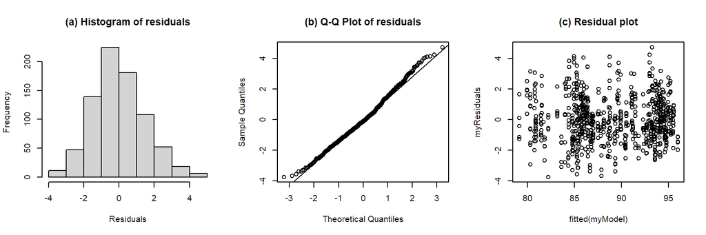

```
## Formula:  h_f0 ~ foot_syls + pre_syls + fin_phon + (1 | speaker) + (1 | foot_dur) + (1 | nuc_pre_text)
##
## Linear mixed model fit by REML. t-tests use Satterthwaite's method [
## lmerModLmerTest]
## Formula: h_f0_equation
##    Data: nuc_h_f0.trimmed
## Control:
## lmerControl(optimizer = optimizer, calc.derivs = FALSE, optCtrl = list(method = "nlminb",
##     starttests = FALSE, kkt = FALSE))
##
## REML criterion at convergence: 2935.9
##
## Scaled residuals:
##     Min      1Q  Median      3Q     Max
## -2.5267 -0.6766 -0.0847  0.6178  3.1838
##
## Random effects:
##  Groups       Name        Variance  Std.Dev.
##  foot_dur     (Intercept) 7.117e-09 8.436e-05
##  nuc_pre_text (Intercept) 4.434e-01 6.659e-01
##  speaker      (Intercept) 2.101e+01 4.584e+00
##  Residual                 2.187e+00 1.479e+00
## Number of obs: 787, groups:  foot_dur, 316; nuc_pre_text, 12; speaker, 11
##
## Fixed effects:
##             Estimate Std. Error       df t value Pr(>|t|)
## (Intercept)  87.2136     1.5446  14.0379  56.464   <2e-16 ***
## foot_syls2    0.8462     0.9799   5.8275   0.864   0.4220
## foot_syls3    2.2936     0.2142 762.9138  10.708   <2e-16 ***
## foot_syls4    1.5666     0.9797   5.8229   1.599   0.1624
## pre_syls1     0.8185     0.9661   5.5048   0.847   0.4321
## pre_syls2     1.1112     1.2399   5.6553   0.896   0.4067
## pre_syls3     0.9880     1.2400   5.6567   0.797   0.4577
## fin_phonL%   -0.6668     0.3364 765.4295  -1.982   0.0478 *
## ---
## Signif. codes:  0 '***' 0.001 '**' 0.01 '*' 0.05 '.' 0.1 ' ' 1
##
## Correlation of Fixed Effects:
##            (Intr) ft_sy2 ft_sy3 ft_sy4 pr_sy1 pr_sy2 pr_sy3
## foot_syls2 -0.006
```

[output cut: 21 more lines]

```
##
## Backward reduced fixed-effect table:
## Degrees of freedom method: Satterthwaite
##
##           Eliminated  Sum Sq Mean Sq NumDF  DenDF F value   Pr(>F)
## pre_syls           1   1.923   0.641     3   5.76  0.2930  0.82938
## foot_syls          0 253.519  84.506     3  12.72 38.6313 1.17e-06 ***
## fin_phon           0   8.541   8.541     1 767.51  3.9043  0.04852 *
## ---
## Signif. codes:  0 '***' 0.001 '**' 0.01 '*' 0.05 '.' 0.1 ' ' 1
##
## Model found:
## h_f0 ~ foot_syls + fin_phon + (1 | speaker) + (1 | nuc_pre_text)
##
## isSingular(my_model, tol = 1e-05 ) --> FALSE
```

Anova of model: h_f0 ~ foot_syls + pre_syls + fin_phon + (1 | speaker) + (1 | foot_dur) + (1 | nuc_pre_text)

| term | sumsq | meansq | NumDF | DenDF | F value | p.value | signif. |
| --- | --- | --- | --- | --- | --- | --- | --- |
| foot_syls | 252.194 | 84.065 | 3 | 7.769 | 38.431 | 5.177887e-05 | p<0.001 |
| pre_syls | 1.923 | 0.641 | 3 | 5.758 | 0.293 | 8.293991e-01 |  |
| fin_phon | 8.594 | 8.594 | 1 | 765.429 | 3.929 | 4.781879e-02 | p<0.05 |

Conditional and marginal R<sup>2</sup> of model

| R2_conditional | R2_marginal |
| --- | --- |
| 0.91 | 0.02 |

$foot_syls

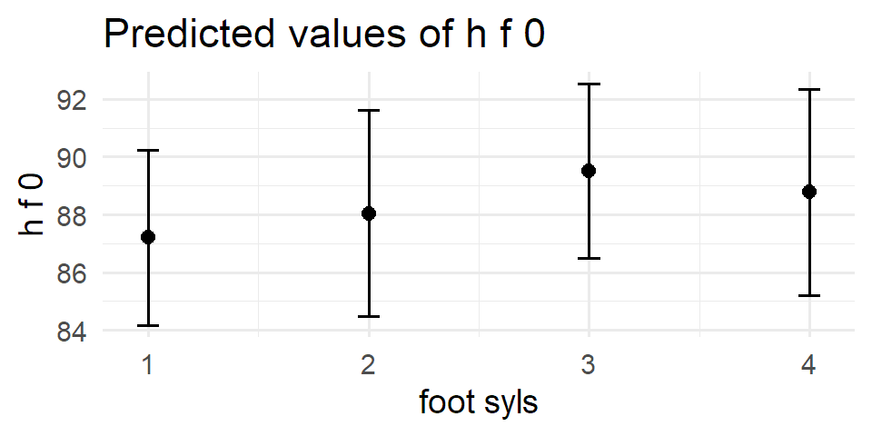

$pre_syls

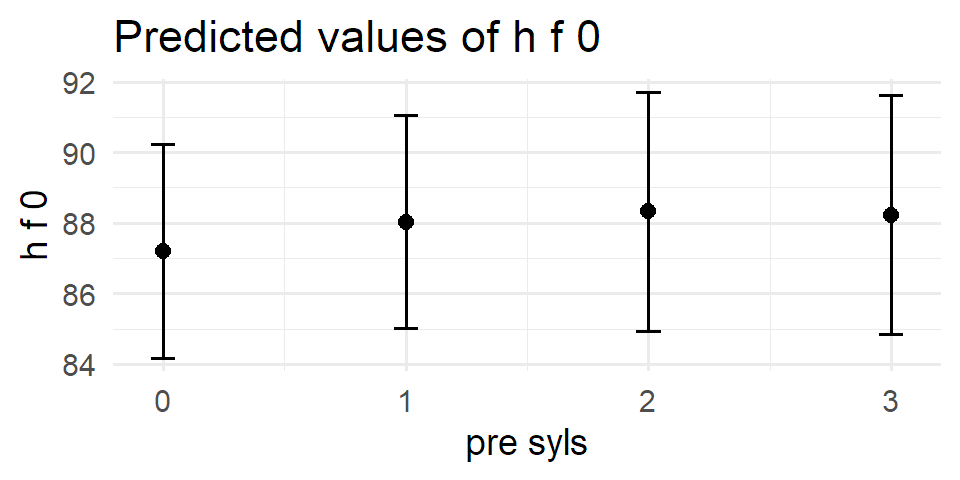

$fin_phon

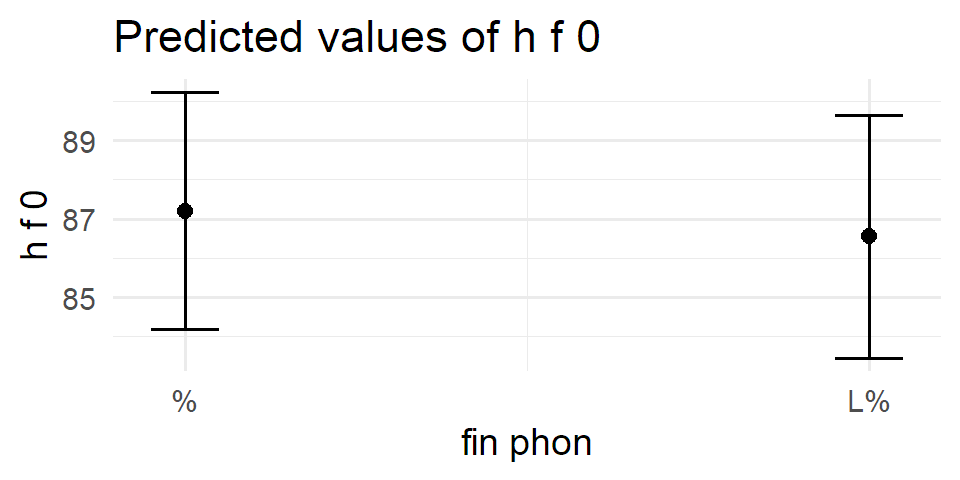

summary of model: h_f0 ~ foot_syls + pre_syls + fin_phon + (1 | speaker) + (1 | foot_dur) + (1 | nuc_pre_text)

| term | estimate | conf.low | conf.high | std.error | t.value | df | p.value |
| --- | --- | --- | --- | --- | --- | --- | --- |
| (Intercept) | 87.203 | 83.8932237 | 90.51196822 | 1.543 | 56.512 | 14.01 | 6.2e-18 |
| foot_syls2 | 0.841 | -1.5633546 | 3.24438940 | 0.975 | 0.862 | 5.83 | 0.4229 |
| foot_syls3 | 2.302 | 1.8760672 | 2.72828991 | 0.217 | 10.607 | 732.14 | 1.5e-24 |
| foot_syls4 | 1.569 | -0.8350554 | 3.97264973 | 0.975 | 1.609 | 5.83 | 0.1603 |
| pre_syls1 | 0.828 | -1.5771190 | 3.23343484 | 0.961 | 0.862 | 5.49 | 0.4249 |
| pre_syls2 | 1.120 | -1.9453590 | 4.18444090 | 1.234 | 0.907 | 5.65 | 0.4012 |
| pre_syls3 | 1.019 | -2.0455163 | 4.08446615 | 1.234 | 0.826 | 5.65 | 0.4421 |
| fin_phonL% | -0.653 | -1.3206936 | 0.01553857 | 0.340 | -1.917 | 765.70 | 0.0556 |

b0 for h_f0 ~ foot_syls + pre_syls + fin_phon + (1 | speaker) + (1 | foot_dur) + (1 | nuc_pre_text)

| intercept | estimate | conf.low | conf.high | std.error | t.value | df | p.value |
| --- | --- | --- | --- | --- | --- | --- | --- |
| foot_syls1 | 87.2 | 83.9 | 90.5 | 1.543 | 56.512 | 14.01 | 6.2e-18 |
| foot_syls2 | 88 | 84.2 | 91.9 | 1.820 | 48.373 | 15.35 | 3.4e-18 |
| foot_syls3 | 89.5 | 86.2 | 92.8 | 1.543 | 58.005 | 14.01 | 4.3e-18 |
| foot_syls4 | 88.8 | 84.9 | 92.6 | 1.820 | 48.772 | 15.35 | 3.0e-18 |
| pre_syls0 | 87.2 | 83.9 | 90.5 | 1.543 | 56.512 | 14.01 | 6.2e-18 |
| pre_syls1 | 88 | 84.7 | 91.3 | 1.544 | 57.026 | 14.03 | 5.2e-18 |
| pre_syls2 | 88.3 | 84.7 | 92 | 1.727 | 51.152 | 15.81 | 5.5e-19 |
| pre_syls3 | 88.2 | 84.6 | 91.9 | 1.727 | 51.089 | 15.81 | 5.5e-19 |

b1 for h_f0 ~ foot_syls + pre_syls + fin_phon + (1 | speaker) + (1 | foot_dur) + (1 | nuc_pre_text)

| intercept | slope | estimate | conf.low | conf.high | std.error | t.value | df | p.value |
| --- | --- | --- | --- | --- | --- | --- | --- | --- |
| foot_syls1 | foot_syls2 | 0.841 | -1.563 | 3.244 | 0.975 | 0.862 | 5.83 | 0.423 |
| foot_syls1 | foot_syls3 | 2.302 | 1.876 | 2.728 | 0.217 | 10.607 | 732.14 | 1.5e-24 |
| foot_syls1 | foot_syls4 | 1.569 | -0.835 | 3.973 | 0.975 | 1.609 | 5.83 | 0.16 |
| foot_syls2 | foot_syls3 | 1.462 | -0.942 | 3.866 | 0.980 | 1.491 | 5.95 | 0.187 |
| foot_syls2 | foot_syls4 | 0.728 | -1.676 | 3.132 | 0.979 | 0.744 | 5.91 | 0.485 |
| foot_syls3 | foot_syls4 | -0.733 | -3.137 | 1.671 | 0.980 | -0.748 | 5.94 | 0.483 |
| pre_syls0 | pre_syls1 | 0.828 | -1.577 | 3.233 | 0.961 | 0.862 | 5.49 | 0.425 |
| pre_syls0 | pre_syls2 | 1.12 | -1.945 | 4.184 | 1.234 | 0.907 | 5.65 | 0.401 |
| pre_syls0 | pre_syls3 | 1.019 | -2.046 | 4.084 | 1.234 | 0.826 | 5.65 | 0.442 |
| pre_syls1 | pre_syls2 | 0.291 | -1.609 | 2.192 | 0.773 | 0.377 | 5.90 | 0.72 |
| pre_syls1 | pre_syls3 | 0.191 | -1.709 | 2.092 | 0.773 | 0.247 | 5.90 | 0.813 |
| pre_syls2 | pre_syls3 | -0.1 | -1.302 | 1.102 | 0.489 | -0.205 | 5.89 | 0.845 |
| intercept | fin_phonL% | -0.653 | -1.321 | 0.016 | 0.340 | -1.917 | 765.70 | 0.056 |

## E targets

### Analysis of E timing

- intercepts only model
- model needs trimming

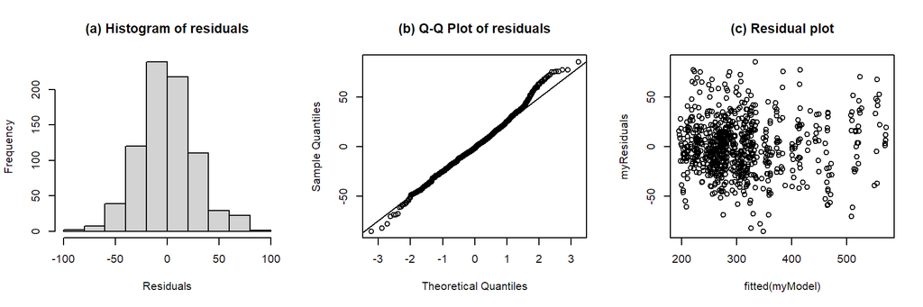

```
## Formula:  e_t ~ foot_syls + pre_syls + fin_phon + gender + nuc_new_word + (1 | speaker) + (1 | foot_dur) + (1 | nuc_pre_text)
##
## Linear mixed model fit by REML. t-tests use Satterthwaite's method [
## lmerModLmerTest]
## Formula: e_t_equation
##    Data: nuc_e_t.trimmed
## Control:
## lmerControl(optimizer = optimizer, calc.derivs = FALSE, optCtrl = list(method = "nlminb",
##     starttests = FALSE, kkt = FALSE))
##
## REML criterion at convergence: 7544.7
##
## Scaled residuals:
##      Min       1Q   Median       3Q      Max
## -3.04118 -0.60982 -0.06261  0.58172  3.04797
##
## Random effects:
##  Groups       Name        Variance Std.Dev.
##  foot_dur     (Intercept)  62.22    7.888
##  nuc_pre_text (Intercept) 443.47   21.059
##  speaker      (Intercept) 687.96   26.229
##  Residual                 793.73   28.173
## Number of obs: 787, groups:  foot_dur, 316; nuc_pre_text, 12; speaker, 11
##
## Fixed effects:
##               Estimate Std. Error      df t value Pr(>|t|)
## (Intercept)    313.326     23.911   7.499  13.104 1.95e-06 ***
## foot_syls2      10.675     30.260   4.983   0.353 0.738683
## foot_syls3     117.213      4.283 733.619  27.367  < 2e-16 ***
## foot_syls4     258.874     34.953   4.990   7.406 0.000713 ***
## pre_syls1      -30.920     30.086   4.869  -1.028 0.352395
## pre_syls2       -4.456     38.700   4.922  -0.115 0.912873
## pre_syls3      -40.541     38.705   4.924  -1.047 0.343562
## fin_phonL%      -5.012      6.631 766.543  -0.756 0.449962
## genderM        -47.809     16.020   8.993  -2.984 0.015356 *
## nuc_new_word0   -4.284     17.487   5.002  -0.245 0.816228
## ---
## Signif. codes:  0 '***' 0.001 '**' 0.01 '*' 0.05 '.' 0.1 ' ' 1
##
## Correlation of Fixed Effects:
```

[output cut: 24 more lines]

```
## Degrees of freedom method: Satterthwaite
##
##              Eliminated Sum Sq Mean Sq NumDF  DenDF  F value    Pr(>F)
## nuc_new_word          1     48      48     1   5.00   0.0600    0.8162
## fin_phon              2    454     454     1 766.88   0.5719    0.4497
## pre_syls              3   6459    2153     3   5.94   2.7183    0.1383
## foot_syls             0 659344  219781     3  12.54 277.4851 1.013e-11 ***
## gender                0   7064    7064     1   8.99   8.9184    0.0153 *
## ---
## Signif. codes:  0 '***' 0.001 '**' 0.01 '*' 0.05 '.' 0.1 ' ' 1
##
## Model found:
## e_t ~ foot_syls + gender + (1 | speaker) + (1 | foot_dur) + (1 | nuc_pre_text)
##
## isSingular(my_model, tol = 1e-05 ) --> FALSE
```

Anova of model: e_t ~ foot_syls + pre_syls + fin_phon + gender + nuc_new_word + (1 | speaker) + (1 | foot_dur) + (1 | nuc_pre_text)

| term | sumsq | meansq | NumDF | DenDF | F value | p.value | signif. |
| --- | --- | --- | --- | --- | --- | --- | --- |
| foot_syls | 636816.836 | 212272.279 | 3 | 6.483 | 267.436 | 3.614573e-07 | p<0.001 |
| pre_syls | 5448.484 | 1816.161 | 3 | 4.958 | 2.288 | 1.968462e-01 |  |
| fin_phon | 453.484 | 453.484 | 1 | 766.543 | 0.571 | 4.499623e-01 |  |
| gender | 7068.914 | 7068.914 | 1 | 8.993 | 8.906 | 1.535643e-02 | p<0.05 |
| nuc_new_word | 47.624 | 47.624 | 1 | 5.002 | 0.060 | 8.162277e-01 |  |

Conditional and marginal R<sup>2</sup> of model

| R2_conditional | R2_marginal |
| --- | --- |
| 0.89 | 0.73 |

$foot_syls

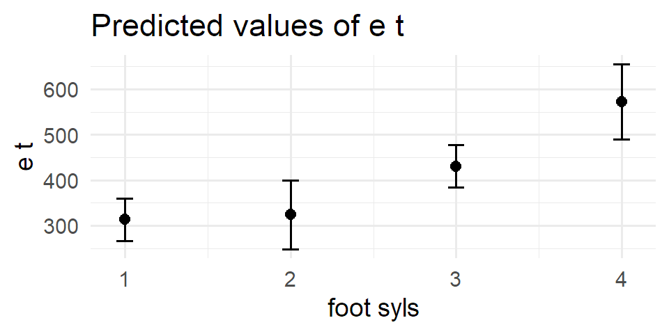

$pre_syls

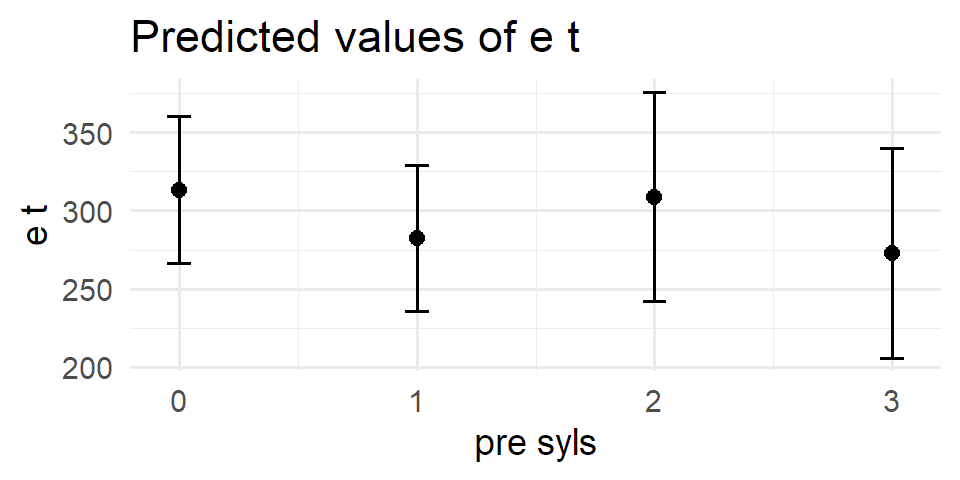

$fin_phon

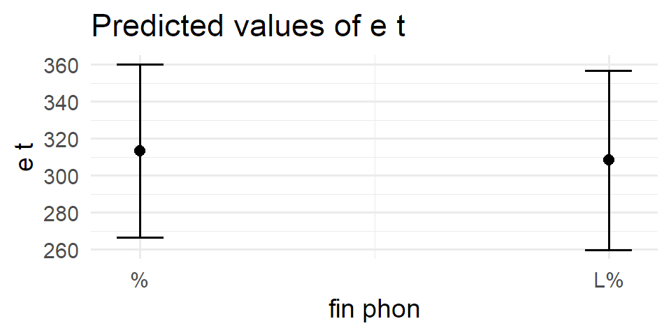

$gender

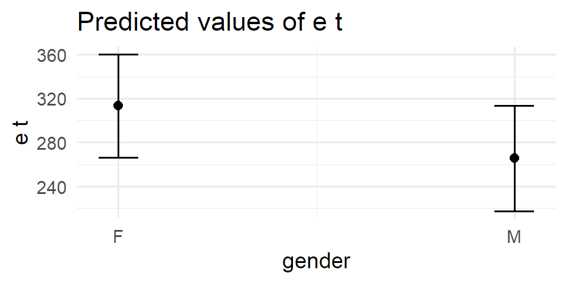

$nuc_new_word

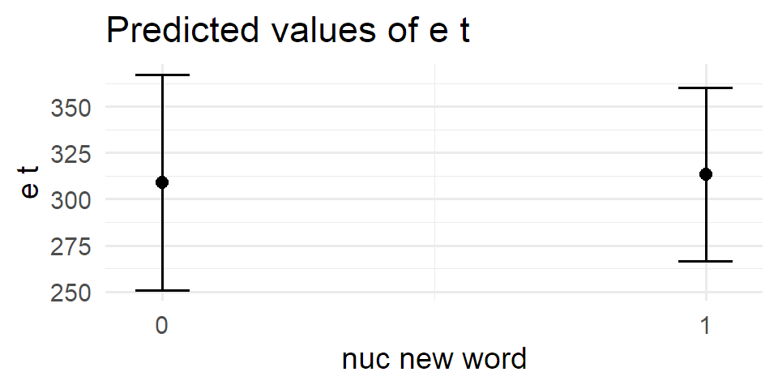

summary of model: e_t ~ foot_syls + pre_syls + fin_phon + gender + nuc_new_word + (1 | speaker) + (1 | foot_dur) + (1 | nuc_pre_text)

| term | estimate | conf.low | conf.high | std.error | t.value | df | p.value |
| --- | --- | --- | --- | --- | --- | --- | --- |
| (Intercept) | 313.326 | 257.54055 | 369.111811 | 23.911 | 13.104 | 7.50 | 1.9e-06 |
| foot_syls2 | 10.675 | -67.18943 | 88.539578 | 30.260 | 0.353 | 4.98 | 0.7387 |
| foot_syls3 | 117.213 | 108.80470 | 125.621657 | 4.283 | 27.367 | 733.62 | 3.5e-114 |
| foot_syls4 | 258.874 | 168.97037 | 348.777902 | 34.953 | 7.406 | 4.99 | 7e-04 |
| pre_syls1 | -30.920 | -108.88550 | 47.045916 | 30.086 | -1.028 | 4.87 | 0.3524 |
| pre_syls2 | -4.456 | -104.41646 | 95.503472 | 38.700 | -0.115 | 4.92 | 0.9129 |
| pre_syls3 | -40.541 | -140.49902 | 59.416836 | 38.705 | -1.047 | 4.92 | 0.3436 |
| fin_phonL% | -5.012 | -18.02917 | 8.004913 | 6.631 | -0.756 | 766.54 | 0.45 |
| genderM | -47.809 | -84.05464 | -11.564147 | 16.020 | -2.984 | 8.99 | 0.0154 |
| nuc_new_word0 | -4.284 | -49.23037 | 40.663314 | 17.487 | -0.245 | 5.00 | 0.8162 |

b0 for e_t ~ foot_syls + pre_syls + fin_phon + gender + nuc_new_word + (1 | speaker) + (1 | foot_dur) + (1 | nuc_pre_text)

| intercept | estimate | conf.low | conf.high | std.error | t.value | df | p.value |
| --- | --- | --- | --- | --- | --- | --- | --- |
| foot_syls1 | 313.3 | 257.5 | 369.1 | 23.911 | 13.104 | 7.50 | 1.9e-06 |
| foot_syls2 | 324 | 228.9 | 419.1 | 38.471 | 8.422 | 5.76 | 1.9e-04 |
| foot_syls3 | 430.5 | 374.8 | 486.3 | 23.909 | 18.008 | 7.50 | 1.9e-07 |
| foot_syls4 | 572.2 | 467.1 | 677.3 | 42.259 | 13.540 | 5.62 | 1.7e-05 |
| pre_syls0 | 313.3 | 257.5 | 369.1 | 23.911 | 13.104 | 7.50 | 1.9e-06 |
| pre_syls1 | 282.4 | 226.6 | 338.2 | 23.926 | 11.803 | 7.52 | 4.0e-06 |
| pre_syls2 | 308.9 | 225.7 | 392.1 | 34.134 | 9.049 | 6.10 | 9.3e-05 |
| pre_syls3 | 272.8 | 189.6 | 356 | 34.137 | 7.991 | 6.10 | 1.9e-04 |

b1 for e_t ~ foot_syls + pre_syls + fin_phon + gender + nuc_new_word + (1 | speaker) + (1 | foot_dur) + (1 | nuc_pre_text)

| intercept | slope | estimate | conf.low | conf.high | std.error | t.value | df | p.value |
| --- | --- | --- | --- | --- | --- | --- | --- | --- |
| foot_syls1 | foot_syls2 | 10.7 | -67.2 | 88.5 | 30.260 | 0.353 | 4.98 | 0.739 |
| foot_syls1 | foot_syls3 | 117.2 | 108.8 | 125.6 | 4.283 | 27.367 | 733.62 | 3.5e-114 |
| foot_syls1 | foot_syls4 | 258.9 | 169 | 348.8 | 34.953 | 7.406 | 4.99 | 7.1e-04 |
| foot_syls2 | foot_syls3 | 106.5 | 28.7 | 184.4 | 30.326 | 3.513 | 5.03 | 0.017 |
| foot_syls2 | foot_syls4 | 248.2 | 158.3 | 338.1 | 34.991 | 7.093 | 5.01 | 8.5e-04 |
| foot_syls3 | foot_syls4 | 141.7 | 51.8 | 231.5 | 34.996 | 4.048 | 5.01 | 0.01 |
| pre_syls0 | pre_syls1 | -30.9 | -108.9 | 47 | 30.086 | -1.028 | 4.87 | 0.352 |
| pre_syls0 | pre_syls2 | -4.456 | -104.4 | 95.5 | 38.700 | -0.115 | 4.92 | 0.913 |
| pre_syls0 | pre_syls3 | -40.5 | -140.5 | 59.4 | 38.705 | -1.047 | 4.92 | 0.344 |
| pre_syls1 | pre_syls2 | 26.5 | -36.1 | 89 | 24.341 | 1.087 | 5.00 | 0.327 |
| pre_syls1 | pre_syls3 | -9.621 | -72.2 | 52.9 | 24.344 | -0.395 | 5.00 | 0.709 |
| pre_syls2 | pre_syls3 | -36.1 | -75 | 2.841 | 15.146 | -2.383 | 5.00 | 0.063 |
| intercept | fin_phonL% | -5.012 | -18 | 8.005 | 6.631 | -0.756 | 766.54 | 0.45 |
| intercept | genderM | -47.8 | -84.1 | -11.6 | 16.020 | -2.984 | 8.99 | 0.015 |
| intercept | nuc_new_word0 | -4.284 | -49.2 | 40.7 | 17.487 | -0.245 | 5.00 | 0.816 |

### Analysis of E F0

- Only intercepts only model avoided convergence and singularity issues
- Speech rate caused massive estimation issues
- model needs trimming (|sd| residuals > 3.5)

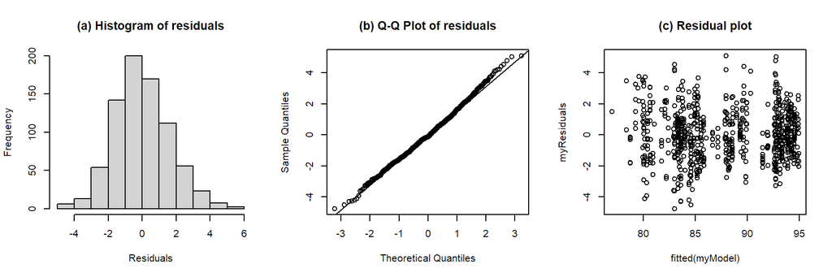

```
## Formula:  e_f0 ~ foot_syls + pre_syls + fin_phon + (1 | speaker) + (1 | nuc_pre_text)
##
## Linear mixed model fit by REML. t-tests use Satterthwaite's method [
## lmerModLmerTest]
## Formula: e_f0_equation
##    Data: nuc_e_f0.trimmed
## Control:
## lmerControl(optimizer = optimizer, calc.derivs = FALSE, optCtrl = list(method = "nlminb",
##     starttests = FALSE, kkt = FALSE))
##
## REML criterion at convergence: 3077.3
##
## Scaled residuals:
##      Min       1Q   Median       3Q      Max
## -2.90760 -0.69406 -0.08096  0.62156  3.12054
##
## Random effects:
##  Groups       Name        Variance Std.Dev.
##  nuc_pre_text (Intercept)  0.2072  0.4552
##  speaker      (Intercept) 24.5542  4.9552
##  Residual                  2.6675  1.6332
## Number of obs: 785, groups:  nuc_pre_text, 12; speaker, 11
##
## Fixed effects:
##             Estimate Std. Error       df t value Pr(>|t|)
## (Intercept)  86.6060     1.5743  12.0086  55.014  8.4e-16 ***
## foot_syls2    1.3680     0.7098   5.3345   1.927    0.108
## foot_syls3    1.6607     0.2365 760.4608   7.021  4.9e-12 ***
## foot_syls4    1.3824     0.7102   5.3446   1.947    0.105
## pre_syls1     0.4969     0.6863   4.6604   0.724    0.504
## pre_syls2     0.2228     0.8891   4.9721   0.251    0.812
## pre_syls3     0.1751     0.8892   4.9704   0.197    0.852
## fin_phonL%   -5.5934     0.3711 765.4684 -15.071  < 2e-16 ***
## ---
## Signif. codes:  0 '***' 0.001 '**' 0.01 '*' 0.05 '.' 0.1 ' ' 1
##
## Correlation of Fixed Effects:
##            (Intr) ft_sy2 ft_sy3 ft_sy4 pr_sy1 pr_sy2 pr_sy3
## foot_syls2 -0.010
## foot_syls3 -0.075  0.132
```

[output cut: 16 more lines]

```
##
## Backward reduced fixed-effect table:
## Degrees of freedom method: Satterthwaite
##
##           Eliminated Sum Sq Mean Sq NumDF  DenDF  F value    Pr(>F)
## pre_syls           1   2.27    0.76     3   5.17   0.2838    0.8356
## foot_syls          0 141.49   47.16     3  14.52  17.6770 4.093e-05 ***
## fin_phon           0 609.64  609.64     1 769.05 228.5026 < 2.2e-16 ***
## ---
## Signif. codes:  0 '***' 0.001 '**' 0.01 '*' 0.05 '.' 0.1 ' ' 1
##
## Model found:
## e_f0 ~ foot_syls + fin_phon + (1 | speaker) + (1 | nuc_pre_text)
##
## isSingular(my_model, tol = 1e-05 ) --> FALSE
```

Anova of model: e_f0 ~ foot_syls + pre_syls + fin_phon + (1 | speaker) + (1 | nuc_pre_text)

| term | sumsq | meansq | NumDF | DenDF | F value | p.value | signif. |
| --- | --- | --- | --- | --- | --- | --- | --- |
| foot_syls | 135.170 | 45.057 | 3 | 7.116 | 16.891 | 1.292741e-03 | p<0.01 |
| pre_syls | 2.271 | 0.757 | 3 | 5.165 | 0.284 | 8.356066e-01 |  |
| fin_phon | 605.917 | 605.917 | 1 | 765.468 | 227.149 | 3.844747e-45 | p<0.001 |

Conditional and marginal R<sup>2</sup> of model

| R2_conditional | R2_marginal |
| --- | --- |
| 0.9 | 0.04 |

$foot_syls

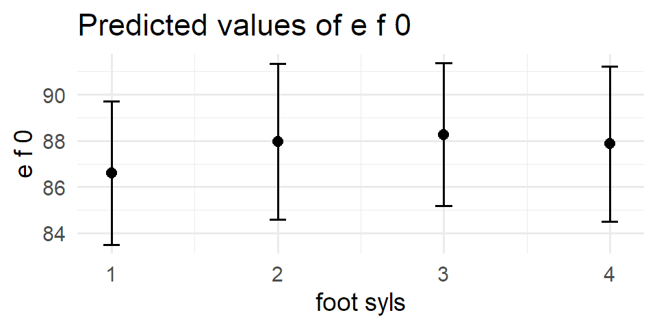

$pre_syls

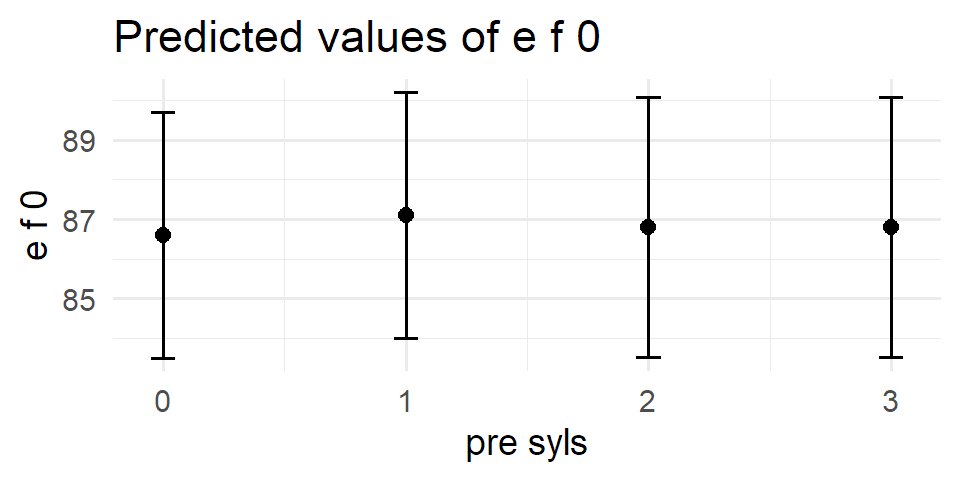

$fin_phon

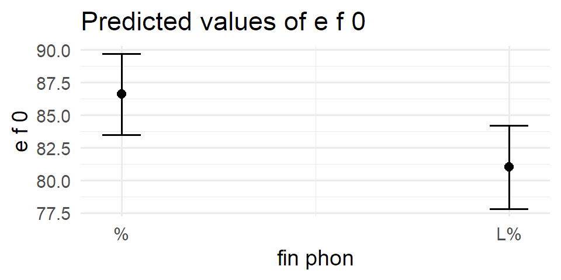

summary of model: e_f0 ~ foot_syls + pre_syls + fin_phon + (1 | speaker) + (1 | nuc_pre_text)

| term | estimate | conf.low | conf.high | std.error | t.value | df | p.value |
| --- | --- | --- | --- | --- | --- | --- | --- |
| (Intercept) | 86.602 | 83.1578577 | 90.046372 | 1.580 | 54.829 | 11.91 | 1.1e-15 |
| foot_syls2 | 1.363 | -0.4010968 | 3.127197 | 0.697 | 1.956 | 5.27 | 0.1049 |
| foot_syls3 | 1.669 | 1.1905259 | 2.146479 | 0.243 | 6.853 | 763.39 | 1.5e-11 |
| foot_syls4 | 1.258 | -0.5060829 | 3.022437 | 0.697 | 1.806 | 5.26 | 0.1278 |
| pre_syls1 | 0.506 | -1.2740627 | 2.285551 | 0.672 | 0.753 | 4.54 | 0.4885 |
| pre_syls2 | 0.203 | -2.0537091 | 2.460093 | 0.871 | 0.233 | 4.88 | 0.8251 |
| pre_syls3 | 0.195 | -2.0620694 | 2.452828 | 0.872 | 0.224 | 4.88 | 0.8317 |
| fin_phonL% | -5.594 | -6.3437517 | -4.844240 | 0.382 | -14.647 | 768.79 | 5.0e-43 |

b0 for e_f0 ~ foot_syls + pre_syls + fin_phon + (1 | speaker) + (1 | nuc_pre_text)

| intercept | estimate | conf.low | conf.high | std.error | t.value | df | p.value |
| --- | --- | --- | --- | --- | --- | --- | --- |
| foot_syls1 | 86.6 | 83.2 | 90 | 1.580 | 54.829 | 11.91 | 1.1e-15 |
| foot_syls2 | 88 | 84.3 | 91.6 | 1.719 | 51.164 | 14.29 | 1.4e-17 |
| foot_syls3 | 88.3 | 84.8 | 91.7 | 1.579 | 55.885 | 11.91 | 8.7e-16 |
| foot_syls4 | 87.9 | 84.2 | 91.5 | 1.719 | 51.102 | 14.29 | 1.4e-17 |
| pre_syls0 | 86.6 | 83.2 | 90 | 1.580 | 54.829 | 11.91 | 1.1e-15 |
| pre_syls1 | 87.1 | 83.7 | 90.6 | 1.580 | 55.124 | 11.93 | 9.8e-16 |
| pre_syls2 | 86.8 | 83.2 | 90.4 | 1.675 | 51.825 | 13.87 | 2.8e-17 |
| pre_syls3 | 86.8 | 83.2 | 90.4 | 1.675 | 51.815 | 13.87 | 2.8e-17 |

b1 for e_f0 ~ foot_syls + pre_syls + fin_phon + (1 | speaker) + (1 | nuc_pre_text)

| intercept | slope | estimate | conf.low | conf.high | std.error | t.value | df | p.value |
| --- | --- | --- | --- | --- | --- | --- | --- | --- |
| foot_syls1 | foot_syls2 | 1.363 | -0.401 | 3.127 | 0.697 | 1.956 | 5.27 | 0.105 |
| foot_syls1 | foot_syls3 | 1.669 | 1.191 | 2.146 | 0.243 | 6.853 | 763.39 | 1.5e-11 |
| foot_syls1 | foot_syls4 | 1.258 | -0.506 | 3.022 | 0.697 | 1.806 | 5.26 | 0.128 |
| foot_syls2 | foot_syls3 | 0.305 | -1.457 | 2.067 | 0.706 | 0.433 | 5.54 | 0.681 |
| foot_syls2 | foot_syls4 | -0.105 | -1.867 | 1.658 | 0.703 | -0.149 | 5.46 | 0.887 |
| foot_syls3 | foot_syls4 | -0.41 | -2.172 | 1.352 | 0.705 | -0.582 | 5.52 | 0.584 |
| pre_syls0 | pre_syls1 | 0.506 | -1.274 | 2.286 | 0.672 | 0.753 | 4.54 | 0.489 |
| pre_syls0 | pre_syls2 | 0.203 | -2.054 | 2.46 | 0.871 | 0.233 | 4.88 | 0.825 |
| pre_syls0 | pre_syls3 | 0.195 | -2.062 | 2.453 | 0.872 | 0.224 | 4.88 | 0.832 |
| pre_syls1 | pre_syls2 | -0.303 | -1.696 | 1.091 | 0.555 | -0.545 | 5.44 | 0.607 |
| pre_syls1 | pre_syls3 | -0.31 | -1.705 | 1.084 | 0.555 | -0.559 | 5.42 | 0.598 |
| pre_syls2 | pre_syls3 | -0.008 | -0.891 | 0.875 | 0.351 | -0.022 | 5.38 | 0.983 |
| intercept | fin_phonL% | -5.594 | -6.344 | -4.844 | 0.382 | -14.647 | 768.79 | 5.0e-43 |